# Examining Social and Spatial Clustering through DBSCAN at the Classic Maya Site of El Perú-Waka’

Sarah Van Oss

2019

**Introduction:**

The levels of social organization present within Maya urban centers have been elusive to scholars since the beginning of archaeology in the region. However, with the introduction of lidar data, the extent of settlement patterns in the Maya Lowlands, specifically in the Petén department of Guatemala, has exponentially expanded our understanding of the nature of Maya settlements. Using this data, I hope to be able to examine the nature of Maya settlement within an urban core and assess the social relationships that accompany specific settlement patterns.

Peterson and Drenan ([2005](https://www.zotero.org/google-docs/?dhljnO)) and Lemonnier (2012) argue that spatial distances among structures reflect social distance among their inhabitants. Peterson and Drenan (2005: 6) argue that “[t]o the extent that daily interactions are important, then, households can be expected to locate their residences close to those of other households with whom they frequently interact.” This organizational pattern would then reflect social communities within a settlement. These social arrangements would then imply a level of informal organization between the household and the site levels.

To examine this kind of social organization at one densely populated site, I examine here the urban center of El Perú-Waka’. This Classic site reflects an unusual settlement pattern in the region as the most densely settled city within the 2016 Pacunam Lidar Initiative (PLI) research area (Canuto et al. 2018). The PLI collected lidar data that represents several sites in the Petén including Tikal and Uaxactun.

This study does not make claims to identify all social organization at the middle level between households and the city. However, to begin this process some basic rules must be assumed. Some of the basic assumptions that I draw upon in this study are:

1. Spatial distance can represent social distance (see Peterson and Drennan 2005, Lemonnier 2012) and can be measured through geometric settlement patterns.
2. The average Maya household is made up of an extended family occupying multiple structures ranging in number from 3 to 10 (see Haviland 1972).
3. A level of social organization exists between the household level and the city level in Classic Maya cities (Arnauld et al. 2012).
4. Clusters of households tend to occur on similar topographical areas and features.

Drawing upon these assumptions, I suggest that three or more extended households within a significantly close spatial proximity could represent a social organization that supersedes the basic household unit. Therefore:

Hypothesis: Spatially significant clusters of ten or more structures exist within the urban core of Waka’.

Null Hypothesis: No spatially significant clusters of ten or more structures exist within the urban core of Waka’.

**Methods:**

*Possible Algorithms*

Initially, I attempted three different kinds of clustering algorithms in QGIS and ArcGIS Pro to examine how the structures within the Waka’ core could be represented in density based spatial groups: k-means, DBSCAN, and HDBSCAN. K-means clustering is an unsupervised algorithm run both programs that creates clusters based on an input parameter of *k* numbers of clusters. DBSCAN (Density Based Cluster Applications with Noise) and HDBSCAN (Hierarchical Density Based Cluster Applications with Noise) use two parameters, a minimum number of points, *n*, and a given raidius, *r,* to create clusters of arbitrary shape. They differ in that HDBSCAN calculates cluster membership using varying densities to determine the likelihood of cluster membership, or cluster stability.

For the present study, DBSCAN is the most appropriate form of analysis for this investigation because it reveals spatial clustering but allows for the identification of “noise”. HDBCSAN was also employed as a comparative tool but as a small area was examined, the need for varying densities was unnecessary and a DBSCAN could produce similar results. Additionally, using a consistent variable allowed for a more easily communicable and replicable process. I elaborate further on the DBSCAN algorithm below. Though there will be some structures that will not be associated with a part of a cluster in this exercise, the statistical identification of the most densely clustered structures will allow for a starting point in continued studies of social organization in the urban core at Waka’.

Density Based Cluster Applications with Noise (DBSCAN) (Ester et al. 1996, Bharti 2019, Anon 2019) represents a statistical analysis that discovers clusters of arbitrary shape within a spatial extent. To accomplish this within a data set all points are assigned a classification as a core, border, or outlier point. These designations are determined by the algorithm using parameters M, minimum number of points, and R, radius. If a radius, R, drawn from point, p, encompasses M points, the point is classified as a core point. If a point, p, is within R distance from a core point but does not have M number of points within its radius, then the point is classified as a border point. A point, p, that does not have M number of points within its R radius, and does not belong to any other cluster, is classified as an outlier. After each point is given a class, the core points are evaluated and connected if they are within R distance of another core point [Fig. 1].

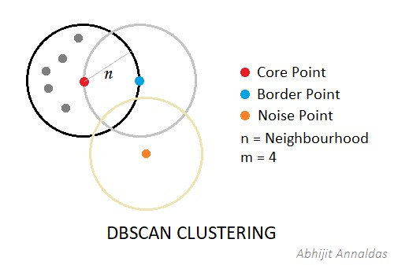

Figure 1: Visual model representing DBSCAN clustering where n represents the radius and m represents the minimum number of points per cluster.

*Identifying Parameters for DBSCAN*

Before running the DBSCAN algorithm, it was necessary to identify appropriate parameters. In this case, structures were given point identifications at the visually identified center of the structure and represent the basic unit of data for this exercise. Thousands of structure points were identified in the lidar data collected in the Waka’ region of the PLI [Fig. 2]. However, as this study aims to examine the structures in only the core, the densest part of the urban area, so this area was isolated through the creation of a new testable data layer. This sample was identified through visual assessment and natural topographic outlines that separated the urban core from outlying settlement areas. The presence of a steep escarpment on the south and south-west edges of the site prevent much settlement outside of the urban core in these directions. To the north and north-east bajos, or low-lying terrains that often held seasonal swamps, prevent the habitation of much of the area outside of the urban core. Though far from uninhabited, there is a more obvious visual differentiation between the urban core and peri-urban settlement areas (terms after Canuto et al. 2019). Therefore, the over 1,000 structures that occupied this area represented the most dense occupation and the urban core in which it would be appropriate to look for spatial clustering in the identification of social units that expanded beyond the extended household [Fig. 3].<sup>[1]</sup>

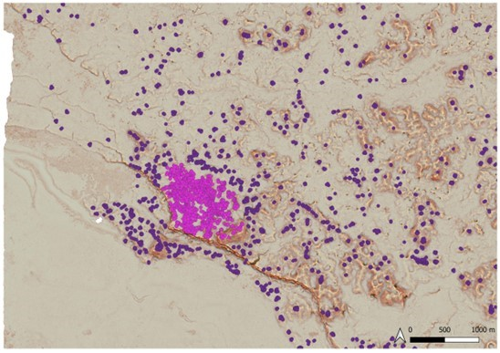

Figure 2: Waka’ survey region showing pink dots as urban core and purple as all identified structures.

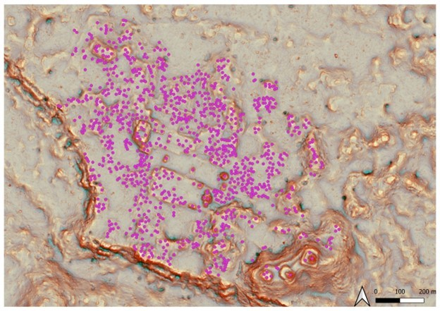

Figure 3: Dots showing all structures designated as within the Waka’ urban core. These dots were then subject to nearest neighbor analysis and DBSCAN.

Using this geographic limitation, it was then necessary to identify if the structures within this area were significantly clustered with one another or if they represented a more normal distribution over the landscape. Nearest neighbor analysis provides a way of approaching this question. When applied to the structure points identified within the above identified area of Waka’ urban core, the results produced were as follows:

Expected Mean Distance (m): 17.032256405968

Nearest Neighbor Index: 0.7976305376462569

Observed Mean Distance (m): 13.585447834421158

Point Count: 1077

Z score: -12.705264549879269

Because the observed mean distance between each point is statistically less than the expected mean distance, the structure points appear to be significantly clustered within the dataset. To explore how this clustering appears in the urban center, we can apply the DBSCAN algorithm to the data.

Next, appropriate parameters for the DBSCAN analysis must be identified. To begin these tests, I used the input of a minimum number of 3 structures because based on ethnoarchaeological studies, Maya households were often inhabited by extended kin groups and were comprised of several structures. An extended household often centered around a central patio where most daily activities took place. Though some households could have more than 3 structures, 3 was identified as the number of structures that surrounded a square patio on most of its sides. Therefore, a minimum number of 3 was identified for the DBSCAN algorithm.

The parameter for the radius was taken from the nearest neighbor analysis. The input for this analysis was the expected mean distance of 17 meters. If structures were randomly, normally spaced across the terrain the average distance between them would be 17. Therefore, the furthest that each structure within a cluster could be from another would be 17 meters. With this radius and a minimum number of structures of 3 the results of the DBSCAN can be found in Fig. 4.

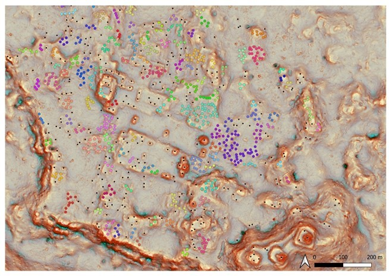

Figure 4: DBSCAN with parameters minimum number of points, p=3 and radius r=17m. Individual clusters were each designated a color by the program. Structures identified as not belonging to any cluster were identified with a smaller black dot.

**Analysis:**

Because households represent the smallest social organizational unit in ancient Maya cities (Arnauld et al. 2012) it was necessary to evaluate the clusters produced with the DBSCAN algorithm and expand tests to include multiple structures. Two associated clusters of structures within a set space could be understood as coincidental but three associated clusters would suggest intentional built communities. Therefore a minimum number of nine structures that make up a social group that extends beyond the household. Additional tests using DBSCAN were conducted with parameters of 6 (as a control test) [Fig. 5] and 9 structures at 17 meter radius [Fig. 6].

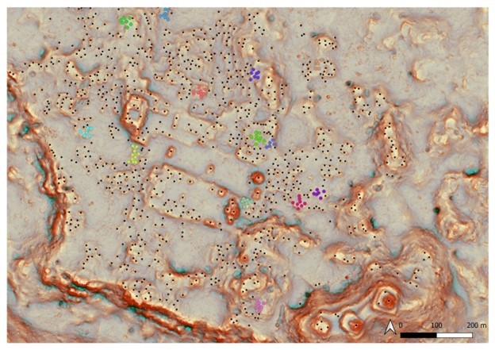

Figure 5: DBSCAN with parameters minimum number of points, p=6 and radius r=17m. Individual clusters were each designated a color by the program. Structures identified as not belonging to any cluster were identified with a smaller black dot.

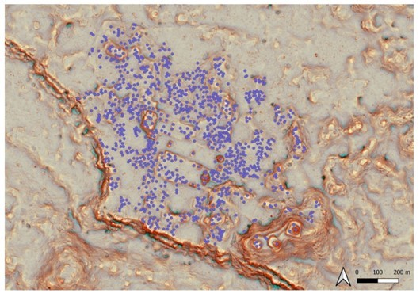

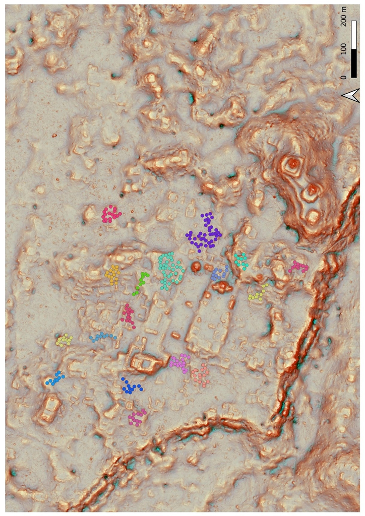

Figure 7: DBSCAN with parameters minimum number of points, p=3 and radius r=17m. Individual clusters were each designated a color by the program. All clusters that contained fewer than 10 structures and all null points were removed from this visualization. The two largest clusters are depicted here in teal and purple.

The 17 clusters identified through these parameters appear throughout the site and in particular to the north and east of the ceremonial center of the city. Most of these clusters range from 10 to 20 structures and are made up of various sizes and shapes of structures. Two groups, however, contain 41 structures of various types. One of these contains what appears to be a small ritual pyramid in the center of a large plaza, though it is the only apparent ceremonial structure to have been placed within a cluster.

Interestingly, the two largest of these clusters are located closest to the largest plaza in the city and the large ceremonial structure that occupies its eastern edge. One occupies a northern edge of the plaza and the other occupies the space behind the eastern pyramid. The next largest groups contain only 18 structures. One of these is located on the western edge of the largest plaza while the other occupies a space further from the center of the city though still within the site core’s area.

Additionally, the majority of these clusters are located adjacent to small features that are low topographical areas likely representing water features. The two largest groups located closest to the largest plaza also are located close to a large topographical depression that has been shown to be a managed water retainment feature (Marken and Ricker 2018). The more northern group shares a distinct border with this water management feature. Though this is unsurprising as water management was a critical part of urban life at Maya cities (Lucero 1999, 2006) ethnoarchaeological patterns also suggest that water management features are central to social organization in the present.

The largest clusters identified through this DBSCAN analysis appear on two sides of the largest plaza within the city and also occupy two sides of a large water management feature. Though it is not apparent what caused these structures or groups to be constructed close together, these patterns suggest that there was a significant relationship among households located in close proximity to one another. The creation of these clusters could have been influenced by access to these two large features of the urban core.

**Conclusions:**

As this is a preliminary exercise, further studies can include an examination of settlement distribution over vertical as well as horizontal space. Additionally, this examination does not intend to perfectly identify social organization at the middle level between the household and the city. Rather it is only intended as one line of evidence to be used in conjunction with material and natural remains uncovered through excavation. Further analysis of structures that takes into account the average size of structures and patios, the types of structures present in cluster groups, and topographical analysis that takes into account the vertical division of space within the urban core may stem from this initial foray into statistical spatial analysis. Additionally, excavation data may be compared to these groups to determine the nature of social interaction that took place within them, potentially expanding these clusters to include adjacent structures not identified as cluster members in the DBSCAN algorithm.

However, the DBSCAN statistical algorithm, drawing on nearest neighbor analysis suggest that the densities present within the urban core of Waka’ are significantly clustered into discrete groups. These spatial clusters can be understood to represent close social relationships among each group’s occupants. These groups suggest that there is a level of social organization that extends beyond the extended kin-group households and is smaller than the urban core. Visual analysis supports this conclusion as natural and constructed features seem to group certain structures together and separate some groups from others.

Going further, this analysis may be used as a starting point in evaluating the existence of Maya neighborhoods within urban settings as well as in rural areas. The continued study of Maya urbanism also will benefit from this kind of analysis as the nature of urbanism reflects the existence of socially heterogeneous groups of people occupying small geographic areas. Clusters of socially and spatially related buildings and people will inform whether these kinds of urban lifeways and relationships existed. These studies are at an important point of growth with the advent of lidar and its abilities to reveal vast amounts of new data from the Maya Lowlands and the ancient cities within the region.

<sup>[1]</sup> In this study, I do not remove monumental structures from the dataset because they do not occupy dense locations within the urban core. Additionally, they can be visually identified easily and their association with certain residential structures could be informative.

Anon

*DBSCAN: Part 1*.

Anon

Density-based Clustering—ArcGIS Pro | ArcGIS Desktop. https://pro.arcgis.com/en/pro-app/tool-reference/spatial-statistics/densitybasedclustering.htm, accessed December 2, 2019b.

Arnauld, M. Charlotte, Linda R. Manzanilla, and Michael E. Smith

2012 *The Neighborhood as a Social and Spatial Unit in Mesoamerican Cities*. University of Arizona Press, Tucson.

Bharti, Vishal

Clustering Algorithm (DBSCAN):27.

Canuto, Marcello A., Francisco Estrada-Belli, Thomas G. Garrison, Stephen D. Houston, Mary Jane Acuña, Milan Kováč, Damien Marken, Philippe Nondédéo, Luke Auld-Thomas, Cyril Castanet, David Chatelain, Carlos R. Chiriboga, Tomáš Drápela, Tibor Lieskovský, Alexandre Tokovinine, Antolín Velasquez, Juan C. Fernández-Díaz, and Ramesh Shrestha

2018 Ancient lowland Maya complexity as revealed by airborne laser scanning of northern Guatemala. *Science* 361(6409):eaau0137. DOI:10.1126/science.aau0137.

Ester, Martin, Hans-Peter Kriegel, and Xiaowei Xu

A Density-Based Algorithm for Discovering Clusters in Large Spatial Databases with Noise:6.

Haviland, William A.

1972 Family Size, Prehistoric Population Estimates, and the Ancient Maya. *American Antiquity* 37(1):135–139. DOI:10.2307/278895.

Hutson, Scott

2016 *The ancient urban Maya: neighborhoods, inequality, and built form*. Edited by John Wayne Janusek, Michael Ernest Smith, and Marilyn A. Masson. Ancient cities of the new world. University Press of Florida, Gainesville ; Tallahassee ; Tampa.

Lemonnier, Eva

2012 Neighborhoods in Classic Lowland Maya Societies:: Their Identification and Definition from the La Joyanca Case Study (Northwestern Petén, Guatemala). In , edited by M. Charlotte Arnauld, Linda R. Manzanilla, and Michael E. Smith, pp. 181–201. University of Arizona Press, Tucson.

Lucero, Lisa J.

1999 Water Control and Maya Politics in the Southern Maya Lowlands. *Archeological Papers of the American Anthropological Association* 9(1):35–49. DOI:10.1525/ap3a.1999.9.1.35.

Lucero, Lisa Joyce

2006 *Water and ritual: the rise and fall of classic Maya rulers*. 1st ed.. Linda Schele series in Maya and pre-Columbian studies. University of Texas Press, Austin.

Marken, Damien B., and Matthew C. Ricker

2018 *LIVING WITH WATER: CLASSIC MAYA POND MANAGEMENT AT EL PERÚ-WAKA’, PETÉN, GUATEMAL*Unpublished National Geographic Society Research Council Grant.

Peterson, Christian E., and Robert D. Drennan

2005 Communities, Settlements, Sites, and Surveys: Regional-Scale Analysis of Prehistoric Human Interaction. *American Antiquity* 70(1):5–30. DOI:10.2307/40035266.